# HW3

## 1

```python
import torch
import torch.nn.functional as F
from torch.utils.data import DataLoader
from torchvision.datasets import FashionMNIST
import torchvision.utils as vutils
import torchvision.transforms as transforms
import torch.nn as nn
import numpy as np
import matplotlib.pyplot as plt
%matplotlib inline
```

```python
class FullyConnectedAutoencoder(nn.Module):
    def __init__(self, out_size):
        super(FullyConnectedAutoencoder, self).__init__()

        self.encoder = nn.Sequential(
            nn.Linear(input_size, 256),
            nn.BatchNorm1d(256),
            nn.ELU(),
            nn.Linear(256, 128),
            nn.BatchNorm1d(128),
            nn.ELU(),
            nn.Linear(128, out_size),
            nn.ELU()
        )

        self.decoder = nn.Sequential(
            nn.Linear(out_size, 128),
            nn.BatchNorm1d(128),
            nn.ELU(),
            nn.Linear(128, 256),
            nn.BatchNorm1d(256),
            nn.ELU(),
            nn.Linear(256, input_size),
            nn.Sigmoid()
        )

    def forward(self, x):
        x = x.view(-1, input_size)
        z = self.encoder(x)
        y = self.decoder(z)
        y = y.view(-1, 1, width, height)
        return y
    def encode(self, x):
        x = x.view(-1, input_size)
        z = self.encoder(x)
        return z
    def decode(self, z):
        y = self.decoder(z)
        y = y.view(-1, 1, width, height)
        return y
class ConvolutionalAutoencoder(nn.Module):
    def __init__(self, out_size):
        super(ConvolutionalAutoencoder, self).__init__()
        self.econv1 = nn.Conv2d(1, 32, kernel_size = 5, bias = False)
        self.ebatch1 = nn.BatchNorm2d(32)
        self.econv2 = nn.Conv2d(32, 8, kernel_size = 5, bias = False)
        self.ebatch2 = nn.BatchNorm2d(8)
        self.econv3 = nn.Conv2d(8, out_size, kernel_size = 20, bias = True)

        self.dconv1 = nn.ConvTranspose2d(out_size, 8, kernel_size = 20, bias = True)
        self.dbatch1 = nn.BatchNorm2d(8)
        self.dconv2 = nn.ConvTranspose2d(8, 32, kernel_size = 5, bias = False)
        self.dbatch2 = nn.BatchNorm2d(32)
        self.dconv3 = nn.ConvTranspose2d(32, 1, kernel_size = 5, bias = False)

    def encoder(self, x):
        y1 = F.elu(self.ebatch1(self.econv1(x)))
        y2 = F.elu(self.ebatch2(self.econv2(y1)))
        z = F.elu(self.econv3(y2))
        return z

    def decoder(self, z):
        y1 = F.elu(self.dbatch1(self.dconv1(z)))
        y2 = F.elu(self.dbatch2(self.dconv2(y1)))
        x = torch.sigmoid(self.dconv3(y2))
        return x
    def encode(self, x):
        x = x.reshape(-1, 1, 28, 28)
        return self.encoder(x)
    def decode(self, z):
        return self.decoder(z)
    def forward(self, x):
        z = self.encoder(x)
        y = self.decoder(z)
        return y
```

## Load training and testing data

Note how the data is loaded with `train = True`. You can load the test data in a similar fashion, just set `train = False`. Feel free to reuse my plot function!

```python
device = torch.device("cuda:0" if torch.cuda.is_available() else "cpu")

batch_size = 100
test_data = FashionMNIST("./data", train = False, download = True,
                          transform=transforms.ToTensor())
train_data = FashionMNIST("./data", train = True, download = True,
                          transform=transforms.ToTensor())
data_loader = DataLoader(test_data, batch_size = batch_size, shuffle = True)
data_loader_train = DataLoader(train_data, batch_size = 60000, shuffle = True)


train_data_matrix = next(iter(data_loader_train))[0]

width = 28
height = 28
input_size = width * height

def plot_images(batch, rows, cols, title = ""):
    plt.figure(figsize = (rows, cols))
    plt.axis("off")
    plt.title(title)
    plt.imshow(np.transpose(
        vutils.make_grid(batch[:(rows * cols)], nrow = rows, normalize = True).cpu(),
        (1, 2, 0)))
def print_labels(batch, numPerRow):
    for i in range(0, len(batch), numPerRow):
#         print(123)
        print(batch[i: i+numPerRow])


first_batch = next(iter(data_loader))

# print('y: {}'.format(first_batch[1]))
# print_labels(first_batch[1], 10)
```

## 2 Comparing Reconstructed Images

[figure not shown]

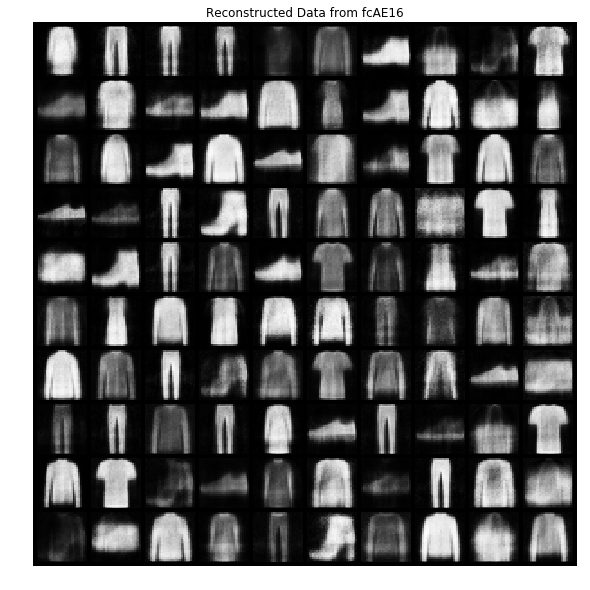

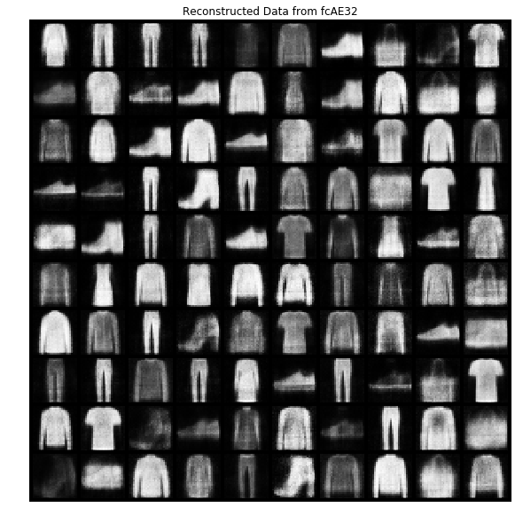

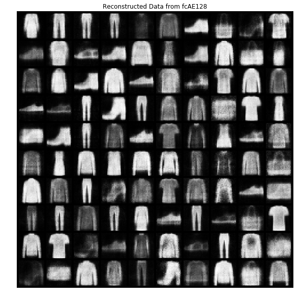

```python
plot_images(first_batch[0], 10, 10, "Testing Data")

fcAE16 = FullyConnectedAutoencoder(16)
fcAE16.load_state_dict(torch.load("fcAE16.pth", map_location=torch.device('cpu')))
reconstructed = fcAE16(first_batch[0])
with torch.no_grad():
    plot_images(reconstructed, 10, 10, "Reconstructed Data from fcAE16")

fcAE32 = FullyConnectedAutoencoder(32)
fcAE32.load_state_dict(torch.load("fcAE32.pth", map_location=torch.device('cpu')))
reconstructed = fcAE32(first_batch[0])
with torch.no_grad():
    plot_images(reconstructed, 10, 10, "Reconstructed Data from fcAE32")

fcAE128 = FullyConnectedAutoencoder(128)
fcAE128.load_state_dict(torch.load("fcAE128.pth", map_location=torch.device('cpu')))
reconstructed = fcAE128(first_batch[0])
with torch.no_grad():
    plot_images(reconstructed, 10, 10, "Reconstructed Data from fcAE128")
```

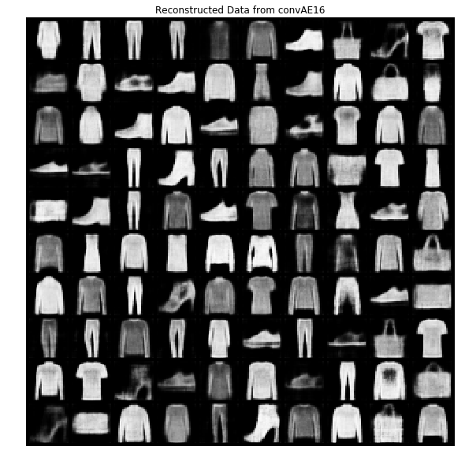

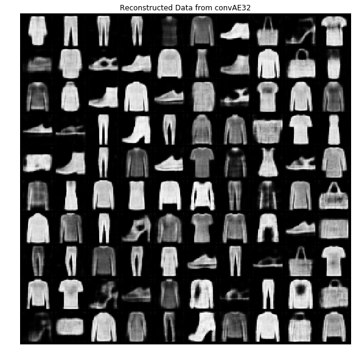

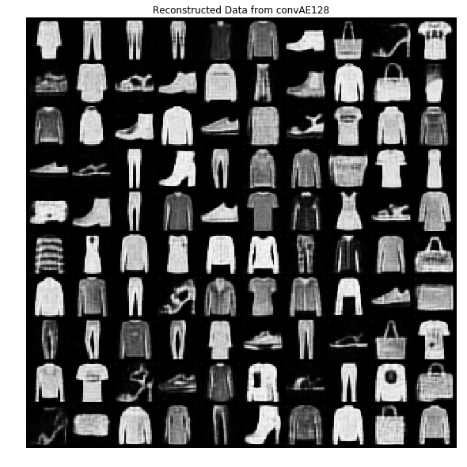

```python
convAE16 = ConvolutionalAutoencoder(16)
convAE16.load_state_dict(torch.load("convAE16.pth", map_location=torch.device('cpu')))
reconstructed = convAE16(first_batch[0])
# print(first_batch[0].shape)
# t = convAE16(first_batch[0])
with torch.no_grad():
    plot_images(reconstructed, 10, 10, "Reconstructed Data from convAE16")

convAE32 = ConvolutionalAutoencoder(32)
convAE32.load_state_dict(torch.load("convAE32.pth", map_location=torch.device('cpu')))
reconstructed = convAE32(first_batch[0])
with torch.no_grad():
    plot_images(reconstructed, 10, 10, "Reconstructed Data from convAE32")

convAE128 = ConvolutionalAutoencoder(128)
convAE128.load_state_dict(torch.load("convAE128.pth", map_location=torch.device('cpu')))
reconstructed = convAE128(first_batch[0])
with torch.no_grad():
    plot_images(reconstructed, 10, 10, "Reconstructed Data from convAE128")
```

The convolutional models reconstructed the images with higher quality. The images reconstructed by the convolutional models are both shaper and preserve more detail. Higher dimensions preserve more detail with both fully connected models and convolutional models. This can be observed especially in patterns on shirts.

## 3. PCA

```python
class PCA_CLASS:
    def init(self, X):
        self.fit(X)
    def fit(self, X):
        # preprocess the data
        X = X.reshape((-1, height*width))
        X_mean = torch.mean(X,0)
        self.mean = X_mean
        X = X - X_mean.expand_as(X)
        # svd
        U,S,V = torch.svd(X)
        self.U, self.S, self.V = U, torch.diag(S), V
#         print(self.U.shape)
#         print(U)
#         print(self.S.shape)
#         print(S)
#         print(self.V.shape)
    def encode(self, X, k):
        X = X.reshape((-1, height*width))
        X = X - self.mean.expand_as(X)
        Vk = self.V[:, :k]
        return X.mm(Vk)
    def decode(self, Z, k):
        Vk = self.V[:, :k]
        X = Z.mm(Vk.t())
        X = X + self.mean.expand_as(X)
        return X.reshape(-1, 1, 28, 28)
```

```python
pca = PCA_CLASS()
pca.fit(train_data_matrix)
```

[figure not shown]

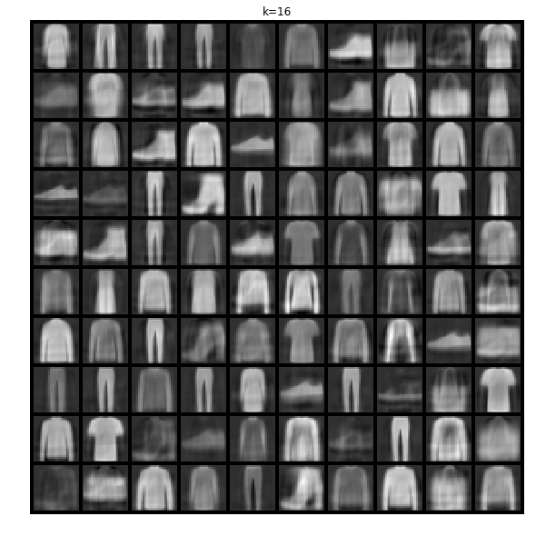

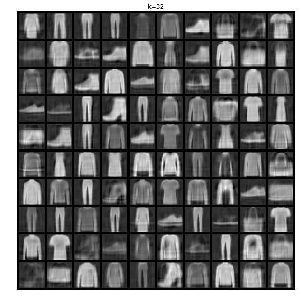

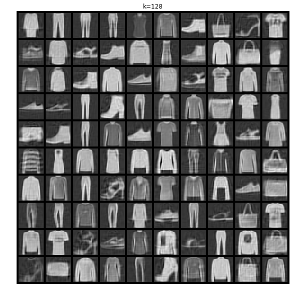

```python
batch = first_batch[0]
k = 128
plot_images(batch, 10, 10, 'original')

for k in [16, 32, 128]:
    test_e = pca.encode(batch, k)
    test_d = pca.decode(test_e, k)
    plot_images(test_d, 10, 10, 'k={}'.format(k))
```

With PCA, the results are a bit worse than with autoencoders, with larger k yielding more detailed images. The resulting images have a grayish tone which wasn't present with autoencoders.

## 4

```python
def getPath(p1, p2, stops):
    path = []
    diff = p2 - p1
    step = diff/(stops+1)
    path.append(p1)
    curr = p1.clone()
    for i in range(stops):
        curr += step
        path.append(curr.clone())
    path.append(p2)
    return path
def interpolate(p1, p2, model):
    model.eval()
    encodedP1 = model.encode(p1)
    encodedP2 = model.encode(p2)
    path = getPath(encodedP1, encodedP2, 10)
    path = [model.decode(p)[0] for p in path]
    return path
```

### With dissimilar images

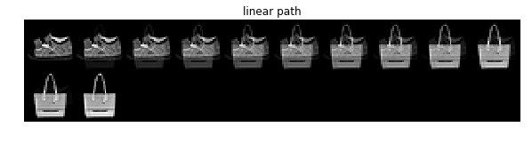

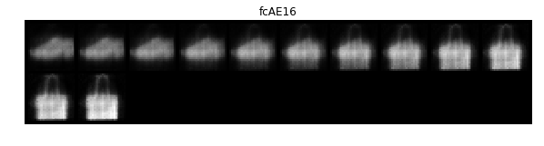

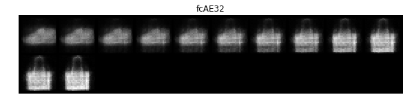

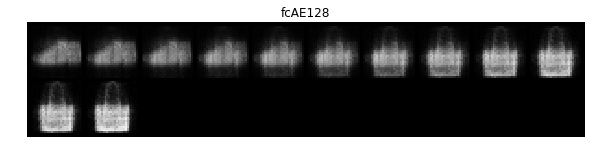

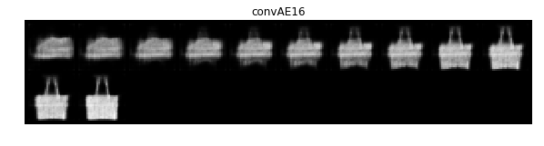

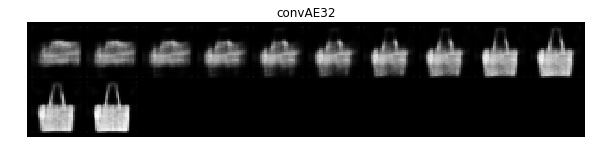

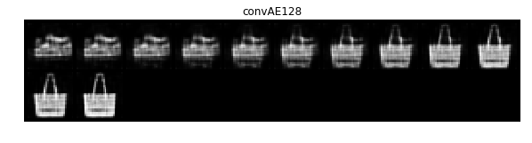

```python
p1 = first_batch[0][10]
p2 = first_batch[0][7]
path = getPath(p1, p2, 10)
plot_images(path, 10, 10, 'linear path')
models = [fcAE16, fcAE32, fcAE128, convAE16, convAE32, convAE128]
names = ['fcAE16', 'fcAE32', 'fcAE128', 'convAE16', 'convAE32', 'convAE128']
for model, name in zip(models, names):
    path = interpolate(p1, p2, model)
    with torch.no_grad():
        plot_images(path, 10, 10, name)
```